# Homework #5

## Instructions

This assignment covers Multidimensional Scaling and nonlinear manifolds through a mixture of theory and coding. You will need the file *Homework5.Rdata* available on Canvas. The commands for loading the data assume this file, *Homework5.Rmd*, and the Rdata file are in the same folder.

You can use the command *cmdscale(d, k , eig = FALSE)* to compute the solution to the classical scaling problem. Here $d$ is a matrix of distances, $k$ is the dimension of the desired configuration, and the option *eig=TRUE* may be added so that eigenvalues are also reported.

For metric MDS, use the command *sammon(d, k, trace = FALSE)* for metric MDS using Sammon’s Stress. Here $d$ is a matrix of distances, $k$ is the dimension of the desired configuration, and the option *trace = FALSE* stops reporting of the stress over iterations of the algorithm.

Use the command *isoMDS(d, k, trace = TRUE)* for nonmetric MDS using the Kruskal Stress-1. As above, $d$ is a matrix of distances, $k$ is the dimension of the desired configuration, and the option *trace = FALSE* stops reporting of the stress over iterations of the algorithm.

Given a data matrix, all pairwise distances can be calculated using the command *dist(x)* where $x$ is the data matrix. The default method is the Euclidean distance. All of the above MDS commands require a matrix of distances or variable of type *dist* given by the output of the *dist()* function.

Complete the following questions and submit your solutions as a *pdf* via Canvas by 11:59 PM on Tuesday November 5th.

## Problems

1. In this problem, we are going to derive the update rule for minimizing Sammon Stress. Given dissimilarities $\delta_{i,j}$ for $1\le i < j \le N$, recall the metric MDS Sammon Stress formula,
   $$Stress(W,\vec{y}_1,\dots,\vec{y_N})= S = \sqrt{\sum_{i,j} W_{ij}(d_{ij} - \delta_{ij})^2.}$$
   where $d_{ij}$ is the distance from $\vec{y}_i$ to $\vec{y}_j$ in $\mathbb{R}^k$ under the Euclidean norm ($d_{ij}^2 = \sum_{k}(y_{ik}-y_{jk})^2$ ) and weights $W_{ij} = \delta_{ij}^{-1}\bigg[\sum_{i<j} \delta_{ij} \bigg]^{-1}$ depending only on the dissimilarities. Sammon developed a method which uses steepest descent, so that if $y_{ij}^{(m)}$ is the $m$th iteration in minimising $S^2$, then
   $$y_{ij}^{(m+1)} = y_{ij}^{(m)} - MF\bigg(\frac{\partial (S^2)}{\partial y_{ij}} \bigg) /\bigg| \frac{\partial^2 (S^2)}{\partial y_{ij}^2}\bigg|$$
   where $MF$ is a *magic factor* to optimize convergence of the algorithm.
   1. Find the partial derivative of $S^2$ with respect to $y_{ij}$, the $j$th coordinate of the $i$th point in the configuration.
   2. Find the second partial derivative of $S^2$ with respect to $y_{ij}$, i.e. $\frac{\partial (S^2)}{\partial y_{ij}^2}.$
2. In some cases, similarities are provided rather than dissimilarities or distances. A matrix $C \in \mathbb{R}^{N\times N}$ is a similarity matrix if it is symmetric and
   $$c_{rs} \le c_{rr}, \quad \text{ for all } r,s.$$
   The standard transformation from a similarity matrix $C$ to a distance matrix $D$ is defined by
   $$d_{rs} = (c_{rr}- 2c_{rs}+c_{ss})^{1/2}.$$
   For all subproblems, assume that $C$ is a positive semidefinite similarity matrix. (Note, a matrix, $A\in\mathbb{R}^{N\times N}$, is positive semidefinite if $\vec{v}^T A \vec{v} \ge 0$ for all vectors $\vec{v}\in\mathbb{R}^N.$)
   1. Show that $c_{ii}+c_{jj} - 2c_{ij} \ge 0.$
   2. Show that the distances defined by $d_{rs}^2 = c_{rr} + c_{ss} - 2c_{rs}$ satisfy the triangle inequality
      $$d_{rs} + d_{st} \ge d_{rt}, \text{ for all } r,s,t.$$
   3. If $C$ is a positive semidefinite similarity matrix, show that $D$ is Euclidean with centered inner product matrix $B = H CH$ where $H$ is the centering matrix $H = I_N - \frac{1}{N}\mathrm{1}_N\mathrm{1}_N^T$ and $\mathrm{1}_N$ is the vectors in $\mathbb{R}^N$ comprised of all ones.
3. Consider the color-stimuli experiment discussed in class and in the Izenman text. The *similarity* ratings are given in the variable *problem2*. The column names correspond to the wavelength of the colors.
   1. Compute the dissimilarity matrix.
   2. Carry out classical scaling of the data. Generate a plot of all eigenvalues and the configuration in 2-dimensions.
   3. Carry out nonmetric scaling of the data. Generate a plot of the Kruskal Stress as a function of dimension and show the configuration in 2-dimensions. (See Figure 13.3 of the Izenman text for reference).
4. Suppose that $1,\dots,7$ are regions enclosed by unbroken lines in a country shown in the arrangement below.

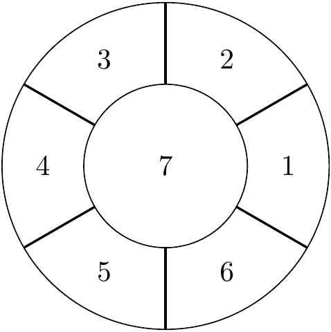

   1. Suppose the distance matrix is constructed by counting the minimum number of boundaries crossed to pass from region $i$ to region $j$. Give the distance matrix, $D$.
   2. Show that the distances constructed this way obey the triangle equality.
   3. Find the eigenvalues in the classical scaling. Is $D$ Euclidean?
   4. Plot coordinates given by the solution to the classical scaling problem in 2-dimensions. Is the original map, from the figure above, reconstructed?
5. Let $D\in \mathbb{R}^{N\times N}$ be Euclidean distance matrix with configuration ${\bf X} = [\vec{x}_1,\dots,\vec{x}_N]^T$ given by the $p$-dimensional principal component scores. Suppose we wish to add an additional point to the configuration usings distances $d_{r,N+1}$ for $r = 1,\dots,N$ which are also Euclidean, allowing for a $(p+1)$-dimensional configuration. If the first $N$ points in the $(p+1)$-dimensional configuration are $\vec{x}_r = (x_{r1},\dots,x_{rp},0)^T$ for $r = 1,\dots,N,$ then show that the $(N+1)$th point is given by $\vec{x}_{N+1} = (\vec{x}^T,y)^T$ where
   $$\vec{x} = \frac{1}{2} {\bf\Lambda^{-1}} {\bf X}^T \vec{f},\qquad \vec{f} = (f_1,\dots,f_N)^T, \qquad f_r = b_{rr}-d^2_{r,N+1}$$
   and
   $$y^2 = \frac{1}{N} \sum_{r=1}^N d^2_{r,N+1} - \frac{1}{N} \sum_{r=1}^N b_{rr} - \| \vec{x}\|^2.$$
   Hence, $\vec{x}$ is uniquely determined but $y$ is determined in absolute value but not in sign.
6. The variables *problem6* contains points on a helix embedded in $\mathbb{R}^{50}$.
   1. Compute the distance matrix under the Euclidean norm and plot the eigenvalues of the classical scaling as a function of dimension. Briefly, discuss the figure and its implications about the dimensionality of the data.
   2. Show the 1, 2, and 3 dimensional configurations in the classical scaling and discuss the differences. Plots in 3D can be generated using the command *scatterplot3d*.